title: Survival driven deconvolution (deSurv) reveals prognostic and interpretable cancer subtypes # Use letters for affiliations, numbers to show equal authorship (if applicable) and to indicate the corresponding author author: - name: Amber M. Young affiliation: a,1,2 - name: Alisa Yurovsky affiliation: b - name: Didong Li affiliation: a - name: Naim U. Rashid affiliation: a,c address: - code: a address: University of North Carolina at Chapel Hill, Biostatistics, Street, City, State, Zip - code: b address: Stony Brook University, Street, City, State, Zip

corresponding_author: code: 2 text: “To whom correspondence should be addressed. E-mail: ayoung31@live.unc.edu”

# For footer text

lead_author_surname: Anonymous

## Remove this if not required

abstract: | Molecular subtyping in cancer is an ongoing problem that relies on the identification of robust and replicable gene signatures. While transcriptomic profiling has revealed recurrent gene expression patterns in various types of cancer, the prognostic value of these signatures is typically evaluated in retrospect. This is due to the reliance on unsupervised learning methods for identifying cell-type-specific signals and clustering patients into molecular subtypes. Here we present a Survival-driven Deconvolution tool (deSurv) that integrates bulk RNA-sequencing data with patient survival information to identify cell-type-enriched gene signatures associated with prognosis. Applying deSurv to various cohorts in pancreatic cancer, we uncover prognostic and biologically interpretable subtypes that reflect the complex interactions between stroma, tumor, and immune cells in the tumor microenvironment. Our approach highlights the value of using patient outcomes during gene signature discovery.

significance: | Tumor transcriptomes reflect mixtures of malignant and microenvironmental cell populations, making it challenging to identify the molecular programs that truly drive clinical outcomes. Existing deconvolution and matrix factorization methods discover latent transcriptional programs but do not ensure that these programs are prognostic, while supervised extensions optimized for prediction offer limited biological interpretability. We present DeSurv, a survival-supervised deconvolution framework that integrates nonnegative matrix factorization with Cox modeling to jointly learn biologically coherent gene programs and their associations with patient survival. By embedding outcome information directly into the discovery process and performing automatic model selection, DeSurv reveals clinically relevant transcriptional programs that are reproducible across cohorts. This approach advances the statistical foundations of tumor deconvolution and provides a general tool for identifying actionable molecular drivers of disease progression.

params: tar_store: ~ bo_label: ~ run_label: ~ val_label: ~

## must be one of: pnasresearcharticle (usual two-column layout), pnasmathematics (one column layout), or pnasinvited (invited submissions only)

pnas_type: pnasresearcharticle

bibliography: references_30102025.bib csl: pnas.csl

## change to true to add optional line numbering

lineno: false

output: rticles::pnas_article

header-includes: -

Molecular subtyping has transformed precision oncology by stratifying patients into biologically and clinically meaningful groups that inform prognosis and guide therapy [@pareja2016triple; @dienstmann2018molecular; @zhou2021clinical; @seiler2017impact; @prat2015clinical]. Subtyping relies on the identification of robust biological signals that define subtypes such as transcriptomic signatures. However, the tumor microenvironment (TME) contains mixtures of diverse cell types such as malignant, stromal, immune, and endothelial cells, and disentangling tumor specific signals from this mixture can be challenging. As such, subtyping pipelines typically rely on the deconvolution of bulk transcriptomic data or single-cell analysis to discover distinct cell types and their corresponding signatures. Downstream, the signatures are evaluated for clinical relevance such as overall survival or response to treatment.

Separating discovery from validation can risk overfitting and limits biological and clinical generalizability. Identified cell types may capture dataset-specific noise rather than reproducible biological signals, undermining their utility in downstream analyses or therapeutic targeting [@Ou2021, @Planey2016]. Moreover, even when discovered cell types are biologically valid and reproducible, they may not correspond to the cellular programs most relevant for predicting or influencing clinical outcomes [@Prat2014, @ellrott2025classification]. Therefore, there is a clear need for integrative methods that jointly uncover biologically meaningful programs while directly incorporating clinical endpoints to ensure prognostic relevance.

However, integrating patient outcomes into the discovery phase is not straightforward with current technology and methodology. Single-cell transcriptomics can resolve programs at the cellular level, but cohort sizes are often too small to support survival analyses. In contrast, large bulk transcriptomic cohorts with clinical annotations are well-suited for outcome modeling [@tomczak2015review; @zhang2019international], yet deconvolution is needed to disentangle overlapping cellular signals. Reference-based deconvolution methods focus on estimating cell-type proportions from predefined signatures, which limits the utility of these methods for discovery of novel programs [@nguyen2024fourteen].

Here we present DeSurv, a Survival-supervised Deconvolution framework that integrates non-negative matrix factorization (NMF) with Cox proportional hazards modelling. In contrast to fully unsupervised approaches that evaluate survival associations only after the factorization, and to existing supervised NMF models that link outcomes to the subject-level factor loadings, DeSurv integrates survival information directly into the gene signature matrix. This design ensures that the discovered transcriptional programs are not only biologically interpretable but also intrinsically aligned with patient outcomes. To enhance robustness and reproducibility, DeSurv performs automatic parameter selection via Bayesian optimization, addressing the quintessential challenge of rank determination in matrix factorization.

By coupling latent program discovery with direct survival supervision, DeSurv resolves longstanding challenges in disentangling tumor–microenvironment interactions and aligns molecular heterogeneity with clinical outcomes. This unified approach represents a methodological advance in translational cancer genomics and provides a general framework for deriving actionable insights from high-dimensional transcriptomic data.

# Results

## Model Overview

We have developed an integrated framework, DeSurv, that couples Nonnegative Matrix Factorization (NMF) with Cox proportional hazards regression to identify latent gene-expression programs associated with patient survival (Fig. 1). The model takes as input a bulk expression matrix of $p$ genes by $n$ patients ($X_{Train}$) together with corresponding survival times ($y_{Train}$) and censoring indicators ($\delta_{Train}$) (Fig. 1A).

DeSurv optimizes a joint objective combining the NMF reconstruction loss and the Cox model’s log-partial likelihood, weighted by a supervision parameter ($\alpha$) that determines the relative contribution of each term (Fig. 1B):
$$\begin{align}
(1-\alpha)\ &\mathcal{L}_{NMF}(X_{Train} \approx WH)\nonumber \\ -
\alpha\
&\mathcal{L}_{Cox}(X_{Train}^TW\beta,y_{Train},\delta_{Train})
\end{align}$$
When $\alpha=0$, the method reduces to standard unsupervised NMF; when $\alpha>0$, survival information directly guides the learned factors toward prognostic structure.

Within this framework, the product ($X_{Train}^TW$) represents patient-level factor scores - the inferred burden of each latent program across subjects. These factor scores serve as covariates in the Cox model, and their regression coefficients ($\beta$) indicate whether higher activity of a given program corresponds to improved or reduced survival.

Model training yields gene weights ($\hat{W}$), factor loadings ($\hat{H}$), and Cox coefficients ($\hat{\beta}$) (Fig. 1C), where the inner dimension ($k$) specifies the number of latent factors. Genes with high gene weights in one factor and low gene weights in all others define the factor-specific signature genes (Fig. 1D). By integrating survival supervision into the factorization, DeSurv not only reconstructs the underlying expression structure, preserving biologial interpretability, but also guides latent factors to be prognostically informative. Subsequent analyses can therefore focus on the survival-associated gene programs (Fig. 1E).

[figure not shown]

DeSurv overview. Overview of the DeSurv training pipeline. A. The input is a preprocessed bulk gene expression matrix and patient survival outcomes. B. The Desurv model optimizes a joint NMF + Cox loss function. C. The DeSurv model estimates three quantities: Gene weights matrix (W), Subject loadings matrix (H), and regression coefficients from the Cox model (beta). D. We extract the exemplar genes from each signature in the gene weights matrix. E. The exemplar genes from survival associated factors provide prognostic gene signatures.

## Bayesian optimisation selects the DeSurv hyperparameters ($k$, $\alpha$)

We now tune DeSurv with Bayesian optimisation (BO) rather than enumerating a dense cross-validation grid. Each BO evaluation fits the model for a single combination of $k$, $\alpha$, and penalty weights, measuring the mean validation C-index. A Gaussian-process surrogate models this surface and proposes new evaluations that balance exploration and exploitation, allowing the search to concentrate rapidly on high-performing regions.

[figure not shown]

A-B. Best cross-validated C-index per rank and corresponding supervision weight when α is tuned jointly with k. C. Violin plot showing the distribution of CV C-index across all BO runs per k. D. Equivalent BO violin summary when α is fixed to 0. E-F. GP posterior mean and 95% confidence bands of the CV C-index versus k for the supervised and α = 0 searches. G. Conventional NMF diagnostics (cophenetic, dispersion, residuals, explained variance, silhouette, sparseness) for the unsupervised baseline.

## DeSurv provides biologically interpretable gene signatures

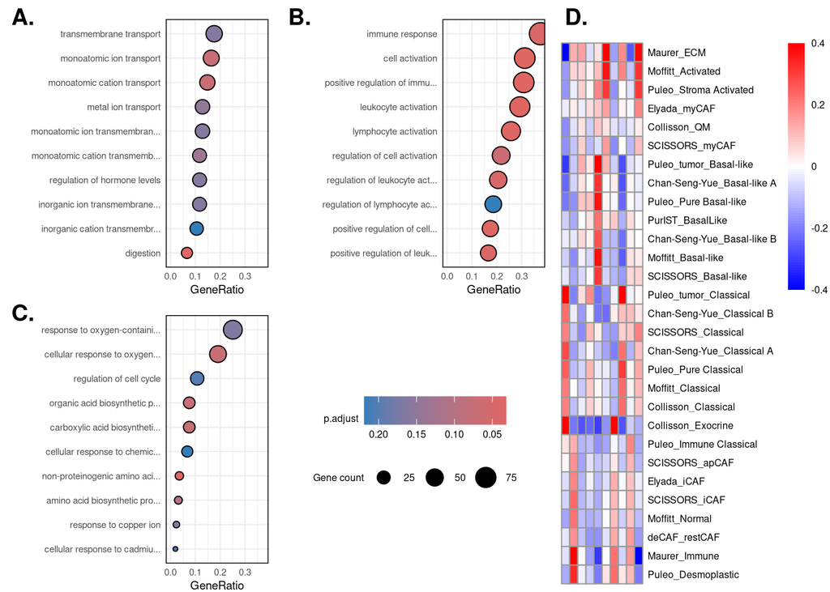

## Analysis of scRNA-seq

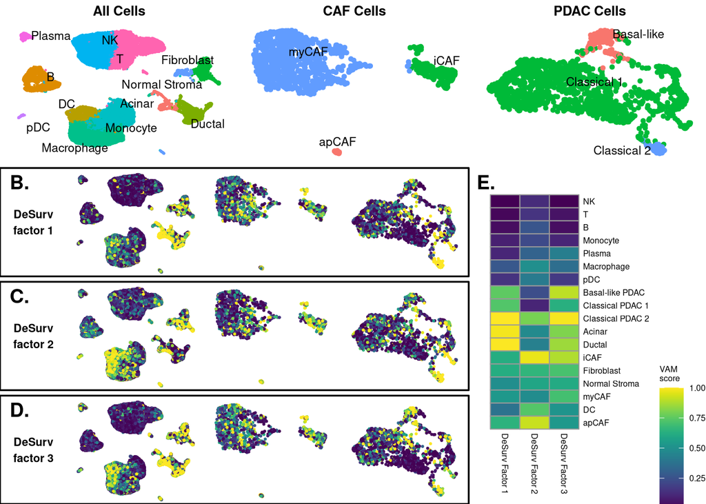

A. Cell type clusters from the Elyada scRNA-seq data. B-D. VAM scores for the DeSurv factor signatures in each cell shown on the UMAP of cells in the Elyada-sc data. E. Heatmap of average VAM scores by cell type and factor signature in the Elyada-sc data.

# Discussion

We present DeSurv, a survival-driven deconvolution framework that integrates nonnegative matrix factorization with Cox proportional hazards modeling to uncover latent gene-expression programs associated with patient outcomes. By coupling unsupervised matrix decomposition with direct survival supervision, DeSurv bridges the gap between descriptive molecular subtyping and prognostic modeling. Unlike conventional NMF, which identifies factors that explain transcriptional variance without regard to clinical relevance, DeSurv simultaneously optimizes reconstruction fidelity and survival discrimination, yielding interpretable gene programs that are both biologically coherent and clinically informative.

In pancreatic ductal adenocarcinoma (PDAC), DeSurv identified three major transcriptional programs corresponding to immune/iCAF, normal/exocrine, and basal-like factors. The immune/iCAF factor was associated with prolonged survival and enriched for inflammatory and immune-response pathways, consistent with prior evidence linking tumor-infiltrating immune and inflammatory fibroblast populations to improved outcomes. In contrast, the basal-like factor was strongly associated with poor survival and enriched for epithelial–mesenchymal transition and cell-cycle programs characteristic of aggressive tumor phenotypes. The normal/exocrine factor, while not prognostic, captured background pancreatic tissue signal and contributed to accurate reconstruction, demonstrating that DeSurv can disentangle prognostic sources of variation while preserving biology.

Importantly, DeSurv outperformed unsupervised NMF in cross-validated concordance index, achieving higher predictive accuracy with fewer factors. This suggests that explicitly incorporating survival information regularizes the factorization, producing a more parsimonious representation that focuses on biologically and clinically relevant variation. Moreover, when applied to independent PDAC cohorts—including Dijk, PACA-AU, Moffitt, and Puleo—DeSurv-derived gene signatures stratified patients into three reproducible clusters with clear prognostic differences. These clusters aligned strongly with existing PurIST and DeCAF classifiers, recapitulating the interplay between tumor-intrinsic (Basal versus Classical) and stromal (proCAF versus restCAF/iCAF) subtypes. Notably, survival prediction appeared to depend on the presence or absence of basal and immune/iCAF programs rather than binary subtype identities, indicating that the co-activation or suppression of these programs better captures the biological continuum of PDAC progression.

Beyond PDAC, DeSurv provides a generalizable framework for discovering prognostic transcriptional programs across complex cancers where tumor and stromal signals are interwoven. By integrating survival modeling into matrix factorization, it unifies molecular deconvolution and outcome prediction within a single, interpretable model. This approach complements both single-cell–based tumor–stroma characterization and bulk expression subtyping, offering a scalable route to translate transcriptomic heterogeneity into clinically actionable prognostic insight. Future work will extend DeSurv to multi-omic data and time-varying outcomes, further enhancing its ability to resolve dynamic tumor–microenvironment interactions that shape disease progression and therapy response.

# Materials and methods

## Problem formulation and notation

Let $X \in \mathbb{R}^{p \times n}_{\ge 0}$ denote the nonnegative gene expression matrix. DeSurv approximates $X \approx WH$, where $W \in \mathbb{R}^{p\times k}_{\ge0}$ contains nonnegative gene programs and $H \in \mathbb{R}^{k\times n}_{\ge0}$ contains sample-level activations. Additionally, let $y,\ \delta \in \mathbb{R}^n$ represent patient survival times and censoring indicators, respectively. Survival outcomes are modeled through a cox proportional hazards model with covariates $Z = W^\top X$.

## The DeSurv Model

DeSurv integrates Nonnegative Matrix Factorization (NMF) with penalized Cox regression to identify gene programs associated with patient survival.

The joint objective is
$$\mathcal{L}(W,H,\beta) =
(1-\alpha)\,\mathcal{L}_{\mathrm{NMF}}(W,H)
- \alpha\,\mathcal{L}_{\mathrm{Cox}}(W,\beta),$$
where $\mathcal{L}_{\mathrm{NMF}}(W,H)$ is the NMF reconstruction error and $\mathcal{L}_{\mathrm{Cox}}(W,\beta)$ is the elastic-net penalized partial log-likelihood. Optimization proceeds by alternating updates for $H$, $W$, and $\beta$, using multiplicative rules for $H$ [@lee1999], projected gradients for $W$, and coordinate descent for $\beta$. Although non-convex, these updates are shown to converge to a stationary point under mild conditions (SI Appendix). Complete derivations and algorithmic details are provided in the SI Appendix.

## Simulation studies

Simulation studies were conducted to assess recovery of prognostic latent structure and survival prediction. Gene expression data were generated from a non-negative factor model $X=WH$, where gene loadings $W$ comprised three gene classes: marker genes, background genes, and noise genes. Marker genes were simulated to load strongly on a single factor and weakly on others, background genes to load strongly across all factors, and noise genes to have uniformly low loadings; each class was generated from a distinct gamma distribution. Sample-level factor activities $H$ were generated from a gamma distribution.

Survival times were generated from an exponential proportional hazards model in which risk depended on marker gene structure through $X^T\tilde{W}$, where $\tilde{W}$ retained marker gene loadings for their corresponding factors and was zero otherwise; censoring times were generated independently from an exponential distribution. Each dataset was analyzed using DeSurv, standard NMF followed by Cox regression on inferred factors, and penalized Cox regression (CoxNet), with all methods tuned using the same cross-validated concordance index. Performance was summarized across repeated simulation replicates.

## Simulations, Benchmarking, and Availability

Let $X \in \mathbb{R}_{\ge 0}^{p \times n}$ denote the nonnegative gene expression matrix with $p$ genes and $n$ subjects. DeSurv approximates $X \approx WH$ with $W \in \mathbb{R}_{\ge 0}^{p \times k}$ and $H \in \mathbb{R}_{\ge 0}^{k \times n}$, and links the shared program matrix $W$ to survival via an elastic-net–penalized Cox model.

Let $y \in \mathbb{R}^n_{\ge 0}$ be the observed survival times, $\delta \in \{0,1\}^n$ the event indicators, and $Z = X^\top W \in \mathbb{R}^{n \times k}$ the sample-wise program loadings. We write $Z_i^\top$ for the $i$th row of $Z$, and $n_{\text{event}} = \sum_{i=1}^n \delta_i$. For convenience we recall the DeSurv loss from Equation~$\ref{eqn:desurv}$ in the main text and rewrite it as
$$\begin{align}
\mathcal{L}(W,H,\beta) &=\nonumber \\
&(1-\alpha)\left(\frac{1}{2np}\lVert X - WH \rVert_F^2 +
\frac{\lambda_H}{2nk} \lVert H \rVert_F^2\right) \nonumber \\
-&\alpha \left(\frac{2}{n_{event}}\ell(W,\beta) - \lambda \{ \xi
\lVert \beta \rVert_1 + \tfrac{1-\xi}{2} \lVert \beta \rVert_2^2 \}
\right) \nonumber
\end{align}$$

where $\lVert \cdot \rVert_F$ is the Frobenius norm and $\beta \in \mathbb{R}^k$ are the Cox coefficients. The Cox log-partial likelihood $\ell(W,\beta)$ is
$$\begin{equation}
\ell(W,\beta)
=
\sum_{i=1}^n
\delta_i
\left[
Z_i^\top \beta
-
\log \left(
\sum_{j : y_j \ge y_i}
\exp(Z_j^\top \beta)
\right)
\right].
\end{equation}$$
Hyperparameters satisfy $\alpha \in [0,1)$, $\lambda_H \ge 0$, $\lambda \ge 0$, and $\xi \in [0,1]$. The constants $1/(2np)$, $2/n_{\text{event}}$, and $1/(2nk)$ are chosen for numerical convenience and do not affect the minimizer.

Conditional on $W$, the loss $\mathcal{L}(W,H,\beta)$ reduces to a strictly convex quadratic function of $H$. We adopt the standard NMF multiplicative update with $\ell_2$ penalty:
$$\begin{equation}
\label{eq:supp-Hupdate}
H \leftarrow
\max\!\left(
H \odot \frac{W^\top X}{
W^\top W H + \lambda_H H + \varepsilon_H
},
\varepsilon_H
\right),
\end{equation}$$
where $\odot$ denotes elementwise multiplication, all divisions are elementwise, and $\varepsilon_H > 0$ is a small floor to prevent entries from becoming exactly zero. This update is equivalent to a majorization–minimization step and guarantees a nonincreasing reconstruction term conditional on $W$ [@lee2001algorithms; @pascualmontano2006nonsmooth]. The $\varepsilon_H$-floor ensures that iterates remain in the interior of the nonnegative orthant, which simplifies the convergence analysis.

For $W$, we construct a hybrid multiplicative update that balances the contributions of the NMF and Cox gradients. Let
$$\nabla_W \mathcal{L}_{\mathrm{NMF}}(W,H)
=
\frac{1}{np}(W H - X)H^\top,$$
and let
$$\nabla_W \mathcal{L}_{\mathrm{Cox}}(W,\beta)
=
\frac{2}{n_{event}}\nabla_W \ell(W,\beta).$$
where $\nabla_W \ell(W,\beta)$ denotes the Cox gradient with respect to $W$. A closed-form expression for $\nabla_W \ell$ is
$$\begin{equation}
\nabla_W \ell(W,\beta)
=
\sum_{i=1}^n
\delta_i
\left(
x_i
-\frac{
\sum_{j : y_j \ge y_i}
x_j \exp(x_j^\top W \beta)
}{
\sum_{j : y_j \ge y_i}
\exp(x_j^\top W \beta)
}
\right)\beta^\top,
\end{equation}$$
where $x_i$ denotes the $i$th column of $X$.

We define the gradient-balancing factor
$$\begin{equation}
\label{eq:supp-delta}
\delta^{(t)}
=
\frac{
\left\lVert (1-\alpha) \nabla_W
\mathcal{L}_{\mathrm{NMF}}(W^{(t)},H^{(t+1)}) \right\rVert_F^2
}{
\left\lVert \alpha \nabla_W \mathcal{L}_{Cox}(W^{(t)},\beta^{(t)})
\right\rVert_F^2
},
\end{equation}$$
and clip $\delta^{(t)}$ to avoid extreme values: $\delta^{(t)} \leftarrow \min(\delta^{(t)}, \delta_{\max})$ with $\delta_{\max} = 10^6$ in all experiments.

The multiplicative factor for $W$ is then
$$\begin{equation}
R^{(t)}
=
\frac{
\frac{(1-\alpha)}{np} X H^{(t+1)\top}
+\frac{2\alpha}{n_{\mathrm{event}}}\,\delta^{(t)}\,\nabla_W
\ell(W^{(t)},\beta^{(t)})
}{
\frac{(1-\alpha)}{np} W^{(t)} H^{(t+1)}H^{(t+1)\top}
+\varepsilon_W
},
\end{equation}$$
and the proposed update is
$$\begin{equation}
\label{eq:supp-Wupdate}
W^{(t+1)}
=
\max\!\left(
W^{(t)} \odot R^{(t)},
\varepsilon_W
\right),
\end{equation}$$
with a small floor $\varepsilon_W > 0$. When $\alpha=0$, this reduces to the standard multiplicative update for NMF [@lee2001algorithms]; for $\alpha>0$, the Cox gradient perturbs the update in a direction that decreases the supervised loss.

Because the combined multiplicative step does not, by itself, guarantee a nonincrease in the full loss $\mathcal{L}$, we embed it in a backtracking line search.

The column normalization preserves both $WH$ and $W\beta$, and therefore leaves the loss $\mathcal{L}$ invariant up to numerical error. Backtracking guarantees that the accepted $W$ update does not increase $\mathcal{L}$.

Conditional on $(W,H)$, the loss in $\beta$ reduces to a convex elastic-net–penalized Cox problem:
$$\min_{\beta \in \mathbb{R}^k}
\left\{
-\frac{2\alpha}{n_{\mathrm{event}}}\,\ell(W,\beta)
+
\lambda\left(
\xi \lVert \beta \rVert_1
+\frac{1-\xi}{2} \lVert \beta \rVert_2^2
\right)
\right\}.$$
We solve this subproblem by cyclic coordinate descent following [@simon2011]. Writing $\ell(\beta) = \ell(W,\beta)$ and $\tilde{\eta}_i = Z_i^\top \beta$, the update for coordinate $r$ has the closed form
$$\begin{equation}
\label{eq:supp-beta-update}
\hat{\beta}_r
=
\frac{
S\!\left(
\dfrac{1}{n}
\sum_{i=1}^n w(\tilde{\eta})_i
z_{i,r}
\left[
v(\tilde{\eta})_i - \sum_{j \ne r} z_{i,j} \beta_j
\right],
\lambda \xi
\right)
}{
\frac{1}{n} \sum_{i=1}^n w(\tilde{\eta})_i z_{i,r}^2 + \lambda(1-\xi)
},
\end{equation}$$
where $S(a,\tau) = \mathrm{sign}(a)\max(|a|-\tau,0)$ is the soft-thresholding operator, and $w(\tilde{\eta})$, $v(\tilde{\eta})$ are standard local quadratic approximations of the Cox log-partial likelihood [@simon2011]. We iterate coordinate updates until the subproblem converges to numerical tolerance, yielding a minimizer in $\beta$ for the current $W$.

After each accepted $W$ update, we normalize the columns of $W$ as $W \leftarrow W D^{-1}$, and adjust $H$ and $\beta$ as
$$H \leftarrow D H, \qquad \beta \leftarrow D \beta,$$
where $D$ is the diagonal matrix of column $\ell_2$-norms of $W$. This preserves the reconstruction $WH$ and the linear predictor $W\beta$, leaving both the NMF and Cox terms in the loss unchanged. Normalization prevents degeneracy in the scale-nonidentifiable factorization and keeps columns of $W$ comparable in magnitude and interpretable as gene programs.

The W update can be derived directly from the projected coordinate descent update with a specific step size.

$$\begin{equation}
\frac{\partial L}{\partial W} = \frac{(1-\alpha)}{np}\left( WHH^T -
XH^T \right) - \frac{2\alpha}{n_{event}} \nabla_W \ell
\end{equation}$$

We show that, under mild regularity conditions, the block coordinate descent (BCD) Algorithm~S$\ref{alg:desurv}$ converges to a stationary point of the DeSurv loss function
$$\mathcal{L}(W,H,\beta).$$
For clarity, we first analyze the algorithm the column normalization of $W$ inside the loop, and then argue in Section~$\ref{subsec:conv_normalization}$ that the normalization step preserves stationarity of limit points.

Throughout, let $\theta = (W,H,\beta)$ and denote $\mathcal{L}(\theta) = \mathcal{L}(W,H,\beta)$. The feasible set is
$$\Theta = \{(W,H,\beta):
W \in \mathbb{R}_{\ge 0}^{p\times k},\;
H \in \mathbb{R}_{\ge 0}^{k\times n},\;
\beta \in \mathbb{R}^k\}.$$

The NMF term $\|X-WH\|_F^2$ is a polynomial in the entries of $W$ and $H$, hence is continuously differentiable. The penalty $\|H\|_F^2$ is continuous as well. The Cox partial log-likelihood is a smooth function of the linear predictor $\eta_i = x_i^\top W \beta$, which is linear in $(W,\beta)$, so this term is continuously differentiable in $(W,\beta)$. The $\ell_2$ penalty on $\beta$ is smooth, and the $\ell_1$ penalty is convex and lower semicontinuous. Therefore $\mathcal{L}$ is continuous on $\Theta$.

The constraints $W,H\ge 0$ define closed convex cones, and $\beta\in\mathbb{R}^k$ is unconstrained. Because $\lambda_H>0$ and $\lambda>0$, the terms $\tfrac{\lambda_H}{nk}\|H\|_F^2$ and $\lambda\tfrac{1-\xi}{2}\|\beta\|_2^2$ dominate the objective as $\|H\|_F\to\infty$ or $\|\beta\|_2\to\infty$, respectively. Thus the sublevel set $\mathcal{S}_0$ is bounded in $(H,\beta)$. Since $W\ge 0$ and $X$ is fixed, the reconstruction term and Cox term being bounded prevent $W$ from diverging while $\mathcal{L}$ remains below $\mathcal{L}(\theta^{(0)})$, so $W$ is bounded on $\mathcal{S}_0$. Because $\Theta$ is closed and $\mathcal{L}$ is continuous, $\mathcal{S}_0$ is closed. Nonemptiness follows from $\theta^{(0)}\in\mathcal{S}_0$. $\square$

By Assumption 2(i),
$$\mathcal{L}(W^{(t)},H^{(t+1)},\beta^{(t)})
\le
\mathcal{L}(W^{(t)},H^{(t)},\beta^{(t)}).$$
By Assumption 2(ii),
$$\mathcal{L}(W^{(t+1)},H^{(t+1)},\beta^{(t)})
\le
\mathcal{L}(W^{(t)},H^{(t+1)},\beta^{(t)}).$$
By Assumption 2(iii),
$$\mathcal{L}(W^{(t+1)},H^{(t+1)},\beta^{(t+1)})
\le
\mathcal{L}(W^{(t+1)},H^{(t+1)},\beta^{(t)}).$$
Combining these inequalities gives
$$\mathcal{L}(\theta^{(t+1)}) \le \mathcal{L}(\theta^{(t)})\quad\forall
t,$$
so $\{\mathcal{L}(\theta^{(t)})\}$ is monotonically nonincreasing. Since $\mathcal{L}$ is bounded below on $\Theta$, the sequence converges to some finite $\mathcal{L}^*$.

Each iterate lies in $\mathcal{S}_0$ by construction, and $\mathcal{S}_0$ is bounded by Lemma 1. Therefore $\{\theta^{(t)}\}$ is bounded and has at least one limit point by the Bolzano–Weierstrass theorem. $\square$

Let $\{t_j\}$ be a subsequence such that $\theta^{(t_j)}\to\theta^*=(W^*,H^*,\beta^*)$. By continuity of $\mathcal{L}$, $\mathcal{L}(\theta^{(t_j)})\to\mathcal{L}^*$.

1. Conditional on $(W,\beta)$, the $H$-subproblem is
   $$\begin{equation}
   \min_{H \geq 0}\frac{(1-\alpha)}{np}(\lVert X-WH \rVert_F^2 +
   \frac{\lambda_H}{nk}||H||_F^2) + \text{const in $H$},\nonumber
   \end{equation}$$
   a strictly convex quadratic program. The multiplicative update for $H$ is known to be a descent method whose fixed points coincide with the KKT points of this constrained subproblem [@lee2001algorithms; @lin2007multconv]. Since the full objective $\mathcal{L}(\theta^{(t)})$ converges, the per-iteration decrease in $\mathcal{L}$ due to the $H$-update must vanish along $\{t_j\}$. If $H^*$ were not KKT for the $H$-subproblem given $(W^*,\beta^*)$, there would exist a feasible descent direction for $H$ at $(W^*,\beta^*)$, implying that for sufficiently large $j$ the $H$-update would still produce a strict decrease in $\mathcal{L}$, contradicting convergence. Hence $H^*$ satisfies the KKT conditions.
2. Conditional on $(H,\beta)$, the $W$-subproblem is differentiable and convex in $W$ (sum of a quadratic term and a negative Cox partial log-likelihood in a linear predictor). The hybrid multiplicative step with backtracking can be viewed as a projected gradient-like update onto the nonnegative orthant. Under mild conditions on the search direction and step sizes, any limit point of such a projected gradient scheme is a KKT point for the constrained subproblem; see, for example, [@tseng2001; @grippo2000]. If $W^*$ did not satisfy the KKT conditions, there would be a feasible descent direction at $(W^*,H^*,\beta^*)$ and a sufficiently small step that reduces $\mathcal{L}$, which the line search would eventually accept. This would contradict the fact that $\mathcal{L}(\theta^{(t_j)})\to\mathcal{L}^*$. Therefore $W^*$ is KKT for the $W$-subproblem.
3. For fixed $(W,H)$, the $\beta$-subproblem is the convex elastic-net penalized Cox objective. The coordinate descent algorithm converges to the unique minimizer. By Assumption 2(iii),$\beta^{(t+1)}$ is taken to be this minimizer at each iteration. Passing to the limit along $\{t_j\}$ shows that $\beta^*$ is the unique minimizer of the $\beta$-block given $(W^*,H^*)$ and hence satisfies its KKT conditions. $\square$

Part (a) is Lemma 2. For part (b), Lemma 3 shows that any limit point $\theta^*$ is blockwise optimal: each block is optimal (in the KKT sense) when the others are held fixed.

The DeSurv loss can be written as
$$\mathcal{L}(\theta) = f(W,H,\beta) + g(\beta)
+ I_{\{W\ge 0\}}(W) + I_{\{H\ge 0\}}(H),$$
where $f$ is continuously differentiable, $g(\beta)=\lambda\xi\|\beta\|_1$ is a separable convex (possibly nondifferentiable) penalty, and $I_C$ denotes the indicator of a closed convex set $C$. This is the smooth+nonsmooth composite form considered in block coordinate descent analyses such as [@tseng2001]. In this setting, any point that is optimal with respect to each block individually (a block coordinatewise minimizer) is a stationary point for the full problem: equivalently,
$$0 \in \nabla_{W,H} f(W^*,H^*,\beta^*)
+ \partial I_{\{W\ge 0\}}(W^*)
+ \partial I_{\{H\ge 0\}}(H^*),$$
$$0 \in \nabla_\beta f(W^*,H^*,\beta^*)
+ \partial g(\beta^*),$$
which are precisely the KKT conditions for $\min_{\theta\in\Theta}\mathcal{L}(\theta)$. Hence every limit point of Algorithm~S$\ref{alg:desurv}$ is stationary. $\square$

The above analysis omits the column-normalization step for $W$ used in Algorithm~S$\ref{alg:backtrack}$. We briefly argue that this normalization does not affect stationarity of limit points.

Let $D$ be a diagonal matrix with strictly positive diagonal entries. The transformation
$$(W,H,\beta) \mapsto (W',H',\beta') = (W D^{-1},\, D H,\,
D\beta)$$
preserves both the product $WH$ and the linear predictor $W\beta$, and hence leaves $\mathcal{L}$ invariant. The column-normalization step is exactly such a transformation, with $D$ chosen from the column norms of $W$.

Let $\{\theta^{(t)}\}$ be the sequence generated by the algorithm without normalization, and let $\{\tilde{\theta}^{(t)}\}$ be the sequence with normalization. For each $t$ there exists a diagonal $D^{(t)}$ with strictly positive entries such that
$$\tilde{\theta}^{(t)} =
(W^{(t)} D^{(t),-1},\, D^{(t)} H^{(t)},\, D^{(t)}\beta^{(t)}),$$
and $\mathcal{L}(\tilde{\theta}^{(t)}) = \mathcal{L}(\theta^{(t)})$. Thus limit points of $\{\tilde{\theta}^{(t)}\}$ are obtained from limit points of $\{\theta^{(t)}\}$ by such invertible diagonal scalings.

Since the KKT conditions are expressed in terms of the gradients with respect to $WH$ and $W\beta$, and these quantities are invariant under the above scaling, stationarity is preserved under the transformation. Therefore Theorem~1 implies that every limit point of the algorithm is also a stationary point of $\mathcal{L}$ (up to this scaling equivalence), which establishes convergence of the implementation used in practice.

Our implementation updates the $\beta$ block using a Coxnet-style coordinate descent that relies on an approximate Hessian. Consequently, the formal optimality proof is established for an idealized version of the $\beta$ update that assumes exact second-order information. Nonetheless, in empirical applications the approximate update is numerically stable and yields a monotone decrease in the objective, consistent with the behavior predicted by the idealized analysis.

Classical nonnegative matrix factorization (NMF) is non-identifiable: for any invertible matrix $R$ with nonnegative entries, the factorization $(W, H)$ can be transformed to $(W R, R^{-1} H)$ without changing the reconstruction error, yielding multiple valid solutions [@donoho2004nmf; @laurberg2008uniqueness; @gillis2014nmf]. Although normalizing columns of $W$ or rows of $H$ resolves the trivial scaling ambiguity, nonnegative mixing transformations persist, and empirical studies consistently show that the sample-loading matrix $H$ is more sensitive to initialization and local minima than the program matrix $W$ [@brunet2004metagenes; @kim2007sparse; @gillis2012accelerated].

In DeSurv, survival supervision enters through the projection $Z = X^\top W$ in the partial log-likelihood, so that the gradient of the DeSurv loss with respect to the programs is
$$\nabla \mathcal{L} = (1-\alpha) \nabla_W \mathcal{L}_{\mathrm{Cox}}(W,H)
- \alpha\nabla_W \mathcal{L}_{\mathrm{Cox}}(W,\beta),$$
and therefore the update rule for $W$ as in Equation~$\ref{eqn:W_update}$ relies on both the reconstruction term and the supervision term. As such, the gene-program definitions are directly shaped by their association with survival. This mechanism amplifies genes aligned with the hazard gradient and suppresses those that dilute prognostic structure, ensuring that the learned programs encode survival-relevant biological variation.

By contrast, if supervision were applied to the sample loadings $H$, the model could reduce the Cox loss by redistributing patient-specific coefficients while leaving the gene-level programs $W$ nearly unchanged, a behavior documented in multiple supervised variants of NMF and supervised topic models, where supervision applied only to the coefficient matrix modifies $H$ but not the basis $W$ [@cai2011graph; @wang2014supervised; @blei2007slda].

Supervising $W$ also provides a practical advantage for **portability**: because $W$ defines gene-level programs, new samples can be embedded by the closed-form projection $Z_{\text{new}} = X_{\text{new}}^\top W$. In contrast, supervising $H$ would not yield such a mapping; instead, obtaining sample loadings for external datasets would require solving a nonnegative least-squares (NNLS) problem for each new sample, introducing optimization noise and reducing reproducibility.

Together, these considerations motivate supervising through $W$, which shapes the gene programs toward prognostic directions, stabilizes solutions across initializations, and yields biologically interpretable signatures that generalize across cohorts.